{% raw %}

{% endraw %} {% raw %}

{% endraw %} {% raw %}

{% endraw %} {% raw %}

{% endraw %}

## Patching

{% raw %}

`get_dicom_files`[[source]](https://github.com/fastai/fastai/tree/master/fastai/medical/imaging.py#L33)

> `get_dicom_files`(**`path`**, **`recurse`**=*`True`*, **`folders`**=*`None`*)

Get dicom files in `path` recursively, only in `folders`, if specified.

{% endraw %} {% raw %}

{% endraw %} {% raw %}

`Path.dcmread`[[source]](https://github.com/fastai/fastai/tree/master/fastai/medical/imaging.py#L38)

> `Path.dcmread`(**`fn`**:`Path`, **`force`**=*`False`*)

Open a `DICOM` file

{% endraw %} {% raw %}

{% endraw %}

`fastai.medical.imaging` uses `pydicom.dcmread` to read a DICOM file. To view the `header` of a DICOM, specify the `path` of a test file and call `dcmread`.

{% raw %}

```python
TEST_DCM = Path('images/sample.dcm')
dcm = TEST_DCM.dcmread()
dcm
```

```
Dataset.file_meta -------------------------------
(0002, 0000) File Meta Information Group Length  UL: 176
(0002, 0001) File Meta Information Version       OB: b'\x00\x01'
(0002, 0002) Media Storage SOP Class UID         UI: CT Image Storage
(0002, 0003) Media Storage SOP Instance UID      UI: 9999.180975792154576730321054399332994563536
(0002, 0010) Transfer Syntax UID                 UI: Explicit VR Little Endian
(0002, 0012) Implementation Class UID            UI: 1.2.40.0.13.1.1.1
(0002, 0013) Implementation Version Name         SH: 'dcm4che-1.4.38'
-------------------------------------------------
(0008, 0018) SOP Instance UID                    UI: ID_e0cc6a4b5
(0008, 0060) Modality                            CS: 'CT'
(0010, 0020) Patient ID                          LO: 'ID_a107dd7f'
(0020, 000d) Study Instance UID                  UI: ID_6468bdd34a
(0020, 000e) Series Instance UID                 UI: ID_4be303ae64
(0020, 0010) Study ID                            SH: ''
(0020, 0032) Image Position (Patient)            DS: [-125.000, -122.268, 115.936]
(0020, 0037) Image Orientation (Patient)         DS: [1.000000, 0.000000, 0.000000, 0.000000, 0.978148, -0.207912]
(0028, 0002) Samples per Pixel                   US: 1
(0028, 0004) Photometric Interpretation          CS: 'MONOCHROME2'
(0028, 0010) Rows                                US: 256
(0028, 0011) Columns                             US: 256
(0028, 0030) Pixel Spacing                       DS: [0.488281, 0.488281]
(0028, 0100) Bits Allocated                      US: 16
(0028, 0101) Bits Stored                         US: 16
(0028, 0102) High Bit                            US: 15
(0028, 0103) Pixel Representation                US: 1
(0028, 1050) Window Center                       DS: "40.0"
(0028, 1051) Window Width                        DS: "100.0"
(0028, 1052) Rescale Intercept                   DS: "-1024.0"
(0028, 1053) Rescale Slope                       DS: "1.0"
(7fe0, 0010) Pixel Data                          OW: Array of 131072 elements
```

{% endraw %} {% raw %}

```python
type(dcm)
```

```
pydicom.dataset.FileDataset
```

{% endraw %} {% raw %}

`class` `TensorDicom`[[source]](https://github.com/fastai/fastai/tree/master/fastai/medical/imaging.py#L44)

> `TensorDicom`(**`x`**, **`kwargs`) :: `TensorImage`

Inherits from `TensorImage` and converts the `pixel_array` into a `TensorDicom`

{% endraw %} {% raw %}

{% endraw %} {% raw %}

`class` `PILDicom`[[source]](https://github.com/fastai/fastai/tree/master/fastai/medical/imaging.py#L49)

> `PILDicom`() :: `PILBase`

This class represents an image object. To create :py:class:`~PIL.Image.Image` objects, use the appropriate factory functions. There's hardly ever any reason to call the Image constructor directly.

- :py:func:`~PIL.Image.open`

- :py:func:`~PIL.Image.new`

- :py:func:`~PIL.Image.frombytes`

{% endraw %} {% raw %}

{% endraw %} {% raw %}

`Path.png16read`[[source]](https://github.com/fastai/fastai/tree/master/fastai/medical/imaging.py#L63)

> `Path.png16read`()

{% endraw %} {% raw %}

{% endraw %} {% raw %}

`None`[source]

{% endraw %} {% raw %}

{% endraw %} {% raw %}

```python
dcm.pixels
```

```
tensor([[-1024., -1024., -1024.,  ..., -1024., -1024., -1024.],
        [-1024., -1024., -1024.,  ..., -1024., -1024., -1024.],
        [-1024., -1024., -1024.,  ..., -1024., -1024., -1024.],
        ...,
        [-1024., -1024., -1024.,  ..., -1024., -1024., -1024.],
        [-1024., -1024., -1024.,  ..., -1024., -1024., -1024.],
        [-1024., -1024., -1024.,  ..., -1024., -1024., -1024.]])
```

{% endraw %} {% raw %}

`None`[source]

{% endraw %} {% raw %}

{% endraw %}

`scaled_px` uses `RescaleSlope` and `RescaleIntercept` values to correctly scale the image so that they represent the correct tissue densities. You can observe what `scaled_px` does by viewing the the pixel distribution of a dicom image. The histogram below displays the current pixel distribution which shows a pixel range between `-1133` and `2545`.

{% raw %}

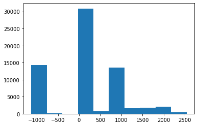

```python
plt.hist(dcm.pixels.flatten().numpy());
```

{% endraw %}

As shown in the `header` of the test image the `RescaleIntercept` has a value of `-1024.0` and a `RescaleSlope` value of `1.0`. `scaled_px` will scale the pixels by these values.

{% raw %}

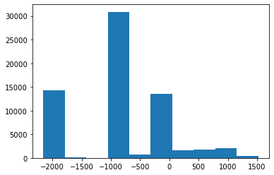

```python
plt.hist(dcm.scaled_px.flatten().numpy());
```

{% endraw %}

The pixel distibution is now between `-2157` and `1521`

{% raw %}

`array_freqhist_bins`[[source]](https://github.com/fastai/fastai/tree/master/fastai/medical/imaging.py#L82)

> `array_freqhist_bins`(**`n_bins`**=*`100`*)

A numpy based function to split the range of pixel values into groups, such that each group has around the same number of pixels

{% endraw %} {% raw %}

{% endraw %} {% raw %}

`Tensor.freqhist_bins`[[source]](https://github.com/fastai/fastai/tree/master/fastai/medical/imaging.py#L92)

> `Tensor.freqhist_bins`(**`n_bins`**=*`100`*)

A function to split the range of pixel values into groups, such that each group has around the same number of pixels

{% endraw %} {% raw %}

{% endraw %}

For example with `n_bins` set to `1` this means the bins will be split into 3 distinct bins (the beginning, the end and the number of bins specified by `n_bins`.

{% raw %}

```python
t_bin = dcm.pixels.freqhist_bins(n_bins=1)
t_bin
```

```
tensor([-1076.,    40.,  2375.])
```

{% endraw %} {% raw %}

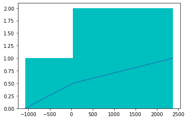

```python
plt.hist(t_bin.numpy(), bins=t_bin, color='c')
plt.plot(t_bin, torch.linspace(0,1,len(t_bin)));
```

{% endraw %}

with `n_bins` at 100

{% raw %}

```python
t_bin = dcm.pixels.freqhist_bins(n_bins=100)
t_bin
```

```
tensor([-1076., -1026., -1024., -1021.,    28.,    30.,    31.,    32.,    33.,
           34.,    35.,    36.,    37.,    38.,    39.,    40.,    41.,    42.,
           44.,    48.,    52.,    58.,    66.,    72.,    76.,    80.,    85.,
           91.,    94.,    98.,   103.,   111.,   123.,   161.,   219.,   478.,
          829.,   999.,  1027.,  1038.,  1044.,  1047.,  1049.,  1050.,  1051.,
         1052.,  1053.,  1054.,  1055.,  1056.,  1057.,  1058.,  1059.,  1060.,
         1062.,  1066.,  1108.,  1265.,  1453.,  1616.,  1741.,  1838.,  1943.,
         2051.,  2220.,  2375.])
```

{% endraw %} {% raw %}

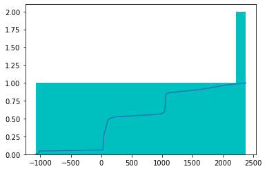

```python
plt.hist(t_bin.numpy(), bins=t_bin, color='c'); plt.plot(t_bin, torch.linspace(0,1,len(t_bin)));
```

{% endraw %} {% raw %}

`Tensor.hist_scaled_pt`[[source]](https://github.com/fastai/fastai/tree/master/fastai/medical/imaging.py#L103)

> `Tensor.hist_scaled_pt`(**`brks`**=*`None`*)

{% endraw %} {% raw %}

{% endraw %} {% raw %}

`Tensor.hist_scaled`[[source]](https://github.com/fastai/fastai/tree/master/fastai/medical/imaging.py#L112)

> `Tensor.hist_scaled`(**`brks`**=*`None`*)

Scales a tensor using `freqhist_bins` to values between 0 and 1

{% endraw %} {% raw %}

{% endraw %}

The test image has pixel values that range between `-1000` and `2500`

{% raw %}

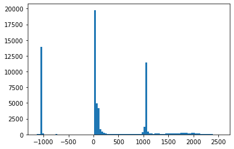

```python
plt.hist(dcm.pixels.flatten().numpy(), bins=100);
```

{% endraw %}

`hist_scaled` provides a way of scaling the input pixel values to between `0` and `1`

{% raw %}

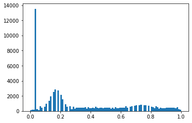

```python
tensor_hists = dcm.pixels.hist_scaled()
plt.hist(tensor_hists.flatten().numpy(), bins=100);
```

{% endraw %} {% raw %}

`Dataset.hist_scaled`[[source]](https://github.com/fastai/fastai/tree/master/fastai/medical/imaging.py#L123)

> `Dataset.hist_scaled`(**`brks`**=*`None`*, **`min_px`**=*`None`*, **`max_px`**=*`None`*)

Pixels scaled to a `min_px` and `max_px` value

{% endraw %} {% raw %}

{% endraw %} {% raw %}

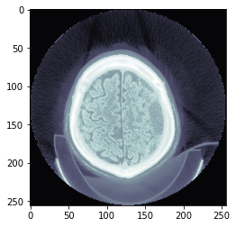

```python
data_scaled = dcm.hist_scaled()
plt.imshow(data_scaled, cmap=plt.cm.bone);
```

{% endraw %} {% raw %}

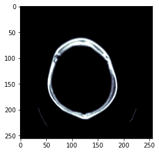

```python
data_scaled = dcm.hist_scaled(min_px=100, max_px=1000)
plt.imshow(data_scaled, cmap=plt.cm.bone);
```

{% endraw %}

Dicom images can contain a high amount of voxel values and windowing can be thought of as a means of manipulating these values in order to change the apperance of the image so particular structures are highlighted. A window has 2 values:

- `l` = window level or center aka brightness
- `w` = window width or range aka contrast

{% raw %}

`Tensor.windowed`[[source]](https://github.com/fastai/fastai/tree/master/fastai/medical/imaging.py#L132)

> `Tensor.windowed`(**`w`**, **`l`**)

Scale pixel intensity by window width and window level

{% endraw %} {% raw %}

{% endraw %} {% raw %}

`Dataset.windowed`[[source]](https://github.com/fastai/fastai/tree/master/fastai/medical/imaging.py#L143)

> `Dataset.windowed`(**`w`**, **`l`**)

{% endraw %} {% raw %}

{% endraw %} {% raw %}

{% endraw %} {% raw %}

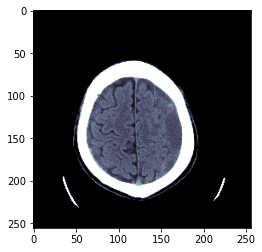

```python
plt.imshow(dcm.windowed(*dicom_windows.brain), cmap=plt.cm.bone);
```

{% endraw %} {% raw %}

`class` `TensorCTScan`[[source]](https://github.com/fastai/fastai/tree/master/fastai/medical/imaging.py#L164)

> `TensorCTScan`(**`x`**, **`kwargs`) :: `TensorImageBW`

Inherits from `TensorImageBW` and converts the `pixel_array` into a `TensorCTScan`

{% endraw %} {% raw %}

{% endraw %} {% raw %}

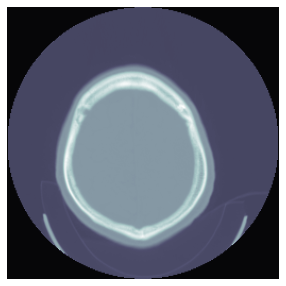

```python
tensor_ct = TensorCTScan(dcm.pixel_array)
tensor_ct.show();
```

{% endraw %} {% raw %}

`class` `PILCTScan`[[source]](https://github.com/fastai/fastai/tree/master/fastai/medical/imaging.py#L169)

> `PILCTScan`() :: `PILBase`

This class represents an image object. To create :py:class:`~PIL.Image.Image` objects, use the appropriate factory functions. There's hardly ever any reason to call the Image constructor directly.

- :py:func:`~PIL.Image.open`

- :py:func:`~PIL.Image.new`

- :py:func:`~PIL.Image.frombytes`

{% endraw %} {% raw %}

{% endraw %} {% raw %}

`Dataset.show`[[source]](https://github.com/fastai/fastai/tree/master/fastai/medical/imaging.py#L183)

> `Dataset.show`(**`frames`**=*`1`*, **`scale`**=*`True`*, **`cmap`**=*`<matplotlib.colors.LinearSegmentedColormap object at 0x7f91a0791850>`*, **`min_px`**=*`-1100`*, **`max_px`**=*`None`*, **`kwargs`)

Adds functionality to view dicom images where each file may have more than 1 frame

{% endraw %} {% raw %}

{% endraw %} {% raw %}

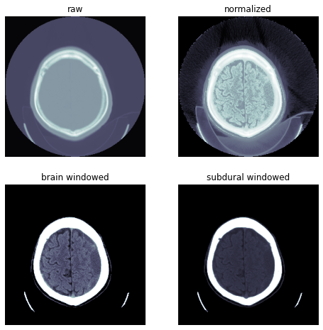

```python
scales = False, True, dicom_windows.brain, dicom_windows.subdural
titles = 'raw','normalized','brain windowed','subdural windowed'
for s,a,t in zip(scales, subplots(2,2,imsize=4)[1].flat, titles):
    dcm.show(scale=s, ax=a, title=t)
```

{% endraw %} {% raw %}

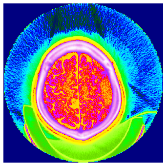

```python
dcm.show(cmap=plt.cm.gist_ncar, figsize=(6,6))
```

{% endraw %}

Some dicom datasets such as the [The Thyroid Segmentation in Ultrasonography Dataset](https://opencas.webarchiv.kit.edu/?q=node/29) is a dataset where each image has multiple frames per file (hundreds in this case). By default the `show` function will display 1 frame but if the dataset has multiple frames you can specify the number of frames to view.

{% raw %}

`Dataset.show`[[source]](https://github.com/fastai/fastai/tree/master/fastai/medical/imaging.py#L183)

> `Dataset.show`(**`frames`**=*`1`*, **`scale`**=*`True`*, **`cmap`**=*`<matplotlib.colors.LinearSegmentedColormap object at 0x7f91a0791850>`*, **`min_px`**=*`-1100`*, **`max_px`**=*`None`*, **`kwargs`)

Adds functionality to view dicom images where each file may have more than 1 frame

{% endraw %} {% raw %}

{% endraw %} {% raw %}

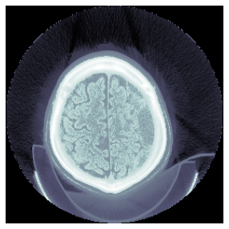

```python
dcm.show()
```

{% endraw %} {% raw %}

`Dataset.pct_in_window`[[source]](https://github.com/fastai/fastai/tree/master/fastai/medical/imaging.py#L198)

> `Dataset.pct_in_window`(**`dcm`**:`DcmDataset`, **`w`**, **`l`**)

% of pixels in the window `(w,l)`

{% endraw %} {% raw %}

{% endraw %} {% raw %}

```python
dcm.pct_in_window(*dicom_windows.brain)
```

```
0.19049072265625
```

{% endraw %}

`pct_in_window` can be used to check what percentage of the image is composed of meaningful pixels (pixels within the specified window)

{% raw %}

`uniform_blur2d`[[source]](https://github.com/fastai/fastai/tree/master/fastai/medical/imaging.py#L205)

> `uniform_blur2d`(**`x`**, **`s`**)

Uniformly apply blurring

{% endraw %} {% raw %}

{% endraw %} {% raw %}

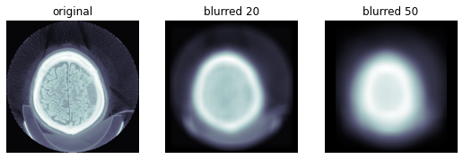

```python
ims = dcm.hist_scaled(), uniform_blur2d(dcm.hist_scaled(), 20), uniform_blur2d(dcm.hist_scaled(), 50)
show_images(ims, titles=('original', 'blurred 20', 'blurred 50'))
```

{% endraw %} {% raw %}

`gauss_blur2d`[[source]](https://github.com/fastai/fastai/tree/master/fastai/medical/imaging.py#L215)

> `gauss_blur2d`(**`x`**, **`s`**)

Apply gaussian_blur2d kornia filter

{% endraw %} {% raw %}

{% endraw %} {% raw %}

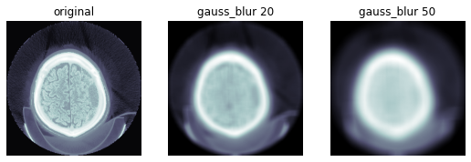

```python
ims = dcm.hist_scaled(), gauss_blur2d(dcm.hist_scaled(), 20), gauss_blur2d(dcm.hist_scaled(), 50)
show_images(ims, titles=('original', 'gauss_blur 20', 'gauss_blur 50'))
```

{% endraw %}

Images are often affected by random variations in intensity values, called noise. Gaussian noise contains variatons in intensity that are drawn from a Gaussian or normal distribution. A Guassian filter is usually used to blur edges and remove smaller or thinner areas in order to preserve the most important information

{% raw %}

`Tensor.mask_from_blur`[[source]](https://github.com/fastai/fastai/tree/master/fastai/medical/imaging.py#L223)

> `Tensor.mask_from_blur`(**`x`**:`Tensor`, **`window`**, **`sigma`**=*`0.3`*, **`thresh`**=*`0.05`*, **`remove_max`**=*`True`*)

Create a mask from the blurred image

{% endraw %} {% raw %}

{% endraw %} {% raw %}

`Dataset.mask_from_blur`[[source]](https://github.com/fastai/fastai/tree/master/fastai/medical/imaging.py#L231)

> `Dataset.mask_from_blur`(**`x`**:`DcmDataset`, **`window`**, **`sigma`**=*`0.3`*, **`thresh`**=*`0.05`*, **`remove_max`**=*`True`*)

Create a mask from the blurred image

{% endraw %} {% raw %}

{% endraw %} {% raw %}

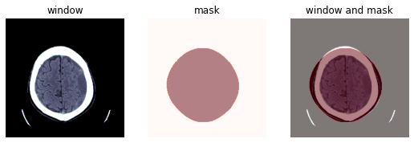

```python
mask = dcm.mask_from_blur(dicom_windows.brain, sigma=0.9, thresh=0.1, remove_max=True)
wind = dcm.windowed(*dicom_windows.brain)

_,ax = subplots(1,3)
show_image(wind, ax=ax[0], title='window')
show_image(mask, alpha=0.5, cmap=plt.cm.Reds, ax=ax[1], title='mask')
show_image(wind, ax=ax[2])
show_image(mask, alpha=0.5, cmap=plt.cm.Reds, ax=ax[2], title='window and mask');
```

{% endraw %} {% raw %}

{% endraw %} {% raw %}

`mask2bbox`[[source]](https://github.com/fastai/fastai/tree/master/fastai/medical/imaging.py#L248)

> `mask2bbox`(**`mask`**)

{% endraw %} {% raw %}

{% endraw %} {% raw %}

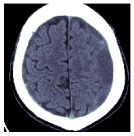

```python
bbs = mask2bbox(mask)
lo,hi = bbs
show_image(wind[lo[0]:hi[0],lo[1]:hi[1]]);
```

{% endraw %} {% raw %}

{% endraw %} {% raw %}

`crop_resize`[[source]](https://github.com/fastai/fastai/tree/master/fastai/medical/imaging.py#L267)

> `crop_resize`(**`x`**, **`crops`**, **`new_sz`**)

{% endraw %} {% raw %}

{% endraw %} {% raw %}

```
torch.Size([1, 128, 128])
```

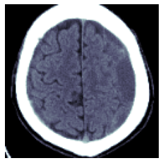

```python
px256 = crop_resize(to_device(wind[None]), bbs[...,None], 128)[0]
show_image(px256)
px256.shape
```

{% endraw %}

Comparing the original image with the image from using the `mask` and `crop_resize` function

{% raw %}

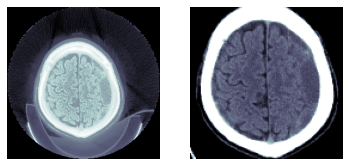

```python
_,axs = subplots(1,2)
dcm.show(ax=axs[0])
show_image(px256, ax=axs[1]);
```

{% endraw %} {% raw %}

`Tensor.to_nchan`[[source]](https://github.com/fastai/fastai/tree/master/fastai/medical/imaging.py#L280)

> `Tensor.to_nchan`(**`x`**:`Tensor`, **`wins`**, **`bins`**=*`None`*)

{% endraw %} {% raw %}

{% endraw %} {% raw %}

`Dataset.to_nchan`[[source]](https://github.com/fastai/fastai/tree/master/fastai/medical/imaging.py#L288)

> `Dataset.to_nchan`(**`x`**:`DcmDataset`, **`wins`**, **`bins`**=*`None`*)

{% endraw %} {% raw %}

{% endraw %}

`to_nchan` takes a tensor or a dicom as the input and returns multiple one channel images (the first depending on the choosen `windows` and a normalized image). Setting `bins` to `0` only returns the windowed image.

{% raw %}

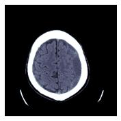

```python
show_images(dcm.to_nchan([dicom_windows.brain], bins=0))
```

{% endraw %} {% raw %}

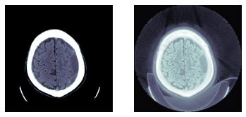

```python
show_images(dcm.to_nchan([dicom_windows.brain], bins=None))
```

{% endraw %} {% raw %}

`Tensor.to_3chan`[[source]](https://github.com/fastai/fastai/tree/master/fastai/medical/imaging.py#L293)

> `Tensor.to_3chan`(**`x`**:`Tensor`, **`win1`**, **`win2`**, **`bins`**=*`None`*)

{% endraw %} {% raw %}

{% endraw %} {% raw %}

`Dataset.to_3chan`[[source]](https://github.com/fastai/fastai/tree/master/fastai/medical/imaging.py#L298)

> `Dataset.to_3chan`(**`x`**:`DcmDataset`, **`win1`**, **`win2`**, **`bins`**=*`None`*)

{% endraw %} {% raw %}

{% endraw %} {% raw %}

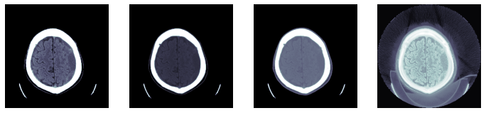

```python
show_images(dcm.to_nchan([dicom_windows.brain,dicom_windows.subdural,dicom_windows.abdomen_soft]))
```

{% endraw %} {% raw %}

`Tensor.save_jpg`[[source]](https://github.com/fastai/fastai/tree/master/fastai/medical/imaging.py#L303)

> `Tensor.save_jpg`(**`x`**:`(Tensor, DcmDataset)`, **`path`**, **`wins`**, **`bins`**=*`None`*, **`quality`**=*`90`*)

Save tensor or dicom image into `jpg` format

{% endraw %} {% raw %}

`Dataset.save_jpg`[[source]](https://github.com/fastai/fastai/tree/master/fastai/medical/imaging.py#L303)

> `Dataset.save_jpg`(**`x`**:`(Tensor, DcmDataset)`, **`path`**, **`wins`**, **`bins`**=*`None`*, **`quality`**=*`90`*)

Save tensor or dicom image into `jpg` format

{% endraw %} {% raw %}

{% endraw %} {% raw %}

`Tensor.to_uint16`[[source]](https://github.com/fastai/fastai/tree/master/fastai/medical/imaging.py#L312)

> `Tensor.to_uint16`(**`x`**:`(Tensor, DcmDataset)`, **`bins`**=*`None`*)

Convert into a unit16 array

{% endraw %} {% raw %}

`Dataset.to_uint16`[[source]](https://github.com/fastai/fastai/tree/master/fastai/medical/imaging.py#L312)

> `Dataset.to_uint16`(**`x`**:`(Tensor, DcmDataset)`, **`bins`**=*`None`*)

Convert into a unit16 array

{% endraw %} {% raw %}

{% endraw %} {% raw %}

`Tensor.save_tif16`[[source]](https://github.com/fastai/fastai/tree/master/fastai/medical/imaging.py#L319)

> `Tensor.save_tif16`(**`x`**:`(Tensor, DcmDataset)`, **`path`**, **`bins`**=*`None`*, **`compress`**=*`True`*)

Save tensor or dicom image into `tiff` format

{% endraw %} {% raw %}

`Dataset.save_tif16`[[source]](https://github.com/fastai/fastai/tree/master/fastai/medical/imaging.py#L319)

> `Dataset.save_tif16`(**`x`**:`(Tensor, DcmDataset)`, **`path`**, **`bins`**=*`None`*, **`compress`**=*`True`*)

Save tensor or dicom image into `tiff` format

{% endraw %} {% raw %}

{% endraw %} {% raw %}

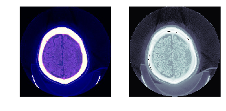

```python
_,axs=subplots(1,2)
with tempfile.TemporaryDirectory() as f:
    f = Path(f)
    dcm.save_jpg(f/'test.jpg', [dicom_windows.brain,dicom_windows.subdural])
    show_image(Image.open(f/'test.jpg'), ax=axs[0])
    dcm.save_tif16(f/'test.tif')
    show_image(Image.open(str(f/'test.tif')), ax=axs[1]);
```

{% endraw %} {% raw %}

`Dataset.set_pixels`[[source]](https://github.com/fastai/fastai/tree/master/fastai/medical/imaging.py#L326)

> `Dataset.set_pixels`(**`px`**)

{% endraw %} {% raw %}

{% endraw %} {% raw %}

`Dataset.zoom`[[source]](https://github.com/fastai/fastai/tree/master/fastai/medical/imaging.py#L333)

> `Dataset.zoom`(**`ratio`**)

Zoom image by specified ratio

{% endraw %} {% raw %}

{% endraw %}

Check to see the current size of the dicom image

{% raw %}

```python
dcm.pixel_array.shape
```

```
(256, 256)
```

{% endraw %} {% raw %}

```
(1792, 1792)
```

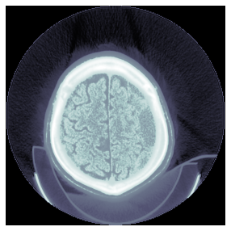

```python
dcm.zoom(7.0)
dcm.show(); dcm.pixel_array.shape
```

{% endraw %} {% raw %}

`Dataset.zoom_to`[[source]](https://github.com/fastai/fastai/tree/master/fastai/medical/imaging.py#L341)

> `Dataset.zoom_to`(**`sz`**)

Change image size to specified pixel size

{% endraw %} {% raw %}

{% endraw %} {% raw %}

```python
dcm.zoom_to(200); dcm.pixel_array.shape
```

```
(200, 200)
```

{% endraw %} {% raw %}

`None`[source]

{% endraw %} {% raw %}

{% endraw %} {% raw %}

```python
dcm2 = TEST_DCM.dcmread()
dcm2.zoom_to(90)
test_eq(dcm2.shape, (90,90))
```

{% endraw %} {% raw %}

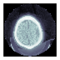

```python
dcm2 = TEST_DCM.dcmread()
dcm2.zoom(0.25)
dcm2.show()
```

{% endraw %} {% raw %}

{% endraw %} {% raw %}

`Dataset.as_dict`[[source]](https://github.com/fastai/fastai/tree/master/fastai/medical/imaging.py#L373)

> `Dataset.as_dict`(**`px_summ`**=*`True`*, **`window`**=*`(80, 40)`*)

Convert the header of a dicom into a dictionary

{% endraw %} {% raw %}

{% endraw %}

`as_dict` takes in 2 parameters: `px_summ` which by default is set to `True` and this returns additional stats such as minimal pixel value, maximum pixel value, the mean pixel value and the image standard deviation. The `window` parameter calculates the `pct_in_window` value depending on the `window` that is specified.

{% raw %}

```python
dcm.as_dict(px_summ=True, window=dicom_windows.brain);
```

{% endraw %} {% raw %}

{% endraw %} {% raw %}

{% endraw %}

Creating a dataframe of the values within the `header` of the dicom

{% raw %}

```python
pneumothorax_source = untar_data(URLs.SIIM_SMALL)
items = get_dicom_files(pneumothorax_source, recurse=True,  folders='train')
dicom_dataframe = pd.DataFrame.from_dicoms(items, window=dicom_windows.brain, px_summ=True)
dicom_dataframe.head(2).T.tail(5)
```

|  | 0 | 1 |
| --- | --- | --- |
| img_min | 0 | 0 |
| img_max | 254 | 250 |
| img_mean | 160.398 | 114.525 |
| img_std | 53.8549 | 70.7523 |
| img_pct_window | 0.0870295 | 0.326269 |

{% endraw %} {% raw %}

`class` `DicomSegmentationDataLoaders`[[source]](https://github.com/fastai/fastai/tree/master/fastai/medical/imaging.py#L402)

> `DicomSegmentationDataLoaders`(*`loaders`, **`path`**:`(str, Path)`=*`'.'`*, **`device`**=*`None`*) :: `DataLoaders`

Basic wrapper around DICOM `DataLoaders` with factory methods for segmentation problems

{% endraw %} {% raw %}

{% endraw %} {% raw %}

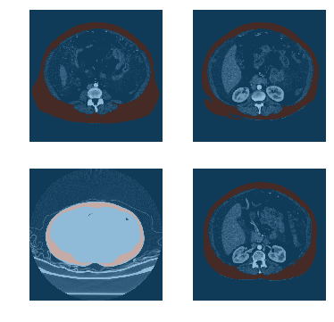

```python
path = untar_data(URLs.TCGA_SMALL)
codes = np.loadtxt(path/'codes.txt', dtype=str)
fnames = get_dicom_files(path/'dicoms')
label_func = lambda o: path/'labels'/f'{o.stem}.png'

dls = DicomSegmentationDataLoaders.from_label_func(path, fnames, label_func, codes=codes, bs=4)
dls.show_batch()
```

{% endraw %}